# Introduction to Latent Dirichlet allocation

This Jupyter Notebook should serve as an introduction to Latent Dirichlet allocation and its underlying concepts. In it an example non optimizied implementation is provided aswell as a description of its mathematical properties. To showcase the model, it is trained on a scraped dataset of news articles containing the word "oil" from the years 2010 - 2018.

## External libraries

Sparse, numpy and scipy are used for vectorizing the code and performing calculations. Scipy is used extensively as well, for the conversion of numpy matrices to sparse matrices, because the memory usage is too high in the LDA model. Nltk is a machine learning libary and is used for text preparation. Bs4 is used for text cleaning as well and pandas for storing data in a dataframe. Finally pathlib is used in order to simplify opening files from the machine.

```python
import csv
from datetime import datetime
from datetime import timezone

import sparse
import numpy
import scipy
from scipy import special
import sys
import nltk
import string
import re
from bs4 import BeautifulSoup
from pathlib import Path
import pandas as pd
import random

nltk.download('punkt')
nltk.download('stopwords')
```

```
True
```

```python
# here we use the file name of the data that was used in order to train the model
# the files source 1- 5 consist out of news articles that have the word oil in it from 2010 -2018
source_list = ["source_1.csv","source_2.csv","source_3.csv","source_4.csv","source_5.csv"]
maxInt = sys.maxsize
while True:
    # decrease the maxInt value by factor 10
    # as long as the OverflowError occurs.

    try:
        csv.field_size_limit(maxInt)
        break
    except OverflowError:
        maxInt = int(maxInt/10)
```

## Helper functions

The function clean_text() is the primary cleaning function, that stems the vocabulary to its base form, removes stop words with the help from the nltk library, calls clean_with_re() in order to clean the text and tokenizes the text.  
sparse_divide_nonzero() is used, because dividing sparse matrices results in them being evaluated as non-sparse matrices, which results in a memory error. Multiplication however does not result in this evaluation problem, therefore 1 is divided element wise by the dividing matrix and the result is multiplied with the other matrix, thus achieving division.

```python
stop_words = set(nltk.corpus.stopwords.words("english"))

def clean_text(text):
    text = BeautifulSoup(text, 'html.parser').get_text()
    text = text.lower().strip()
    text = clean_with_re(text)
    text = text.translate(str.maketrans('','',string.punctuation))
    text = nltk.tokenize.word_tokenize(text)
    stemmer = nltk.stem.PorterStemmer()
    text = result = [i for i in text if not i in stop_words]
    text = [stemmer.stem(i) for i in text]
    return text

def sparse_divide_nonzero(a, b):
    inv_b = b.copy()
    inv_b.data = 1 / inv_b.data
    return a.multiply(inv_b)



def clean_with_re(text):
    text = re.sub(r"[^A-Za-z0-9^,!?.\/'+]", " ", text)
    text = re.sub(r"\+", " plus ", text)
    text = re.sub(r",", " ", text)
    text = re.sub(r"\.", " ", text)
    text = re.sub(r"!", " ! ", text)
    text = re.sub(r"\?", " ? ", text)
    text = re.sub(r"'", " ", text)
    text = re.sub(r":", " : ", text)
    text = re.sub(r"\s{2,}", " ", text)
    text = re.sub(" \d+", " ", text)
    text = re.sub(r'\b\w{1,2}\b', '', text)
    text = re.sub('(?<=[a-z])\'(?=[a-z])', '', text)
    return text
```

In the cell below code is executed in order to extract the data and apply the previously defined text preparation functions on them. As a side note, the whole program assumes that all supporting data is found in the same folder

```python
all_articles = []
for source in source_list:
    print(source)
    filelink = Path("./"+ source)
    with open(filelink,newline='',encoding="utf8") as csvfile:
            csvreader  = csv.reader(csvfile, delimiter=',', quotechar='"')
            next(csvreader, None)
            #print(sum(1 for line in csvreader))
            for row in csvreader :

                try:
                    token_body = clean_text(row[5])
                    all_articles.append({"title":row[0],
                           "unixtimestamp":row[1],
                            "description":row[2],
                            "keywords":row[3],
                            "link":row[4],
                            "article_body":row[5],
                            "tokenized_body" : token_body,
                            "sentiment": article_sentiment_score([get_sentiment(x) for x in nltk.pos_tag(token_body) if get_sentiment(x) is not None]),
                          })
                except:
                    #some articles are without body
                    pass

            csvfile.close()
```

```
source_1.csv
source_2.csv
```

```
source_3.csv
```

```
source_4.csv
source_5.csv
```

```python
#data entered into a dataframe and set to zero in order to free ram
df = pd.DataFrame(all_articles)
df
all_articles = 0
```

# Latent Dirichlet allocation

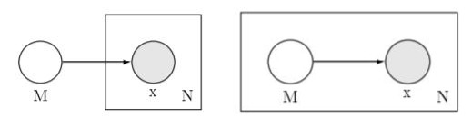

In a graphical depiction of a generative probabilistic model, lighter circles represent latent variables and darker colored colored circles represent non-latent/known variables. As can be deducted from the above presented example, arrows represent dependency and quadratic or rectangular shapes encompass repeated processes.  
Generative in the context of LDA means that LDA assumes that the documents in the corpus are created by the following procedure.

1. Choose number of words $N \sim$ Poisson$(\xi)$
2. Choose a topic distribution $\theta \sim$ Dir$(\alpha)$
3. For each of the $N$ words $w_n$:
   1. Choose a topic $z_n \sim$ Multinominal($\theta$)
   2. Choose a word $w_n$ from $p(w_n |z_n, \beta)$, a multinominal probability conditioned on the topic $z_n$

Every document therefore is generated through the usage of a a word distribution $\beta$ and topic distribution $\theta$ with a predefined number of topics. The word distribution $\beta$ is a V( number of unique terms) by K( number of topics) matrix and reflects how much a topic is believed to be associated to the topics. In the first step of the generative process, the amount of words in a document is determined according to the mean $\xi$. Then the topic distribution is drawn from a Dirichlet distribution, whose density function is determined by the vector $\alpha$. Finally for each word $w_n$ in the document, a topic is chosen from the Multinomial topic distribution of the document and then a word is chosen conditioned on the topic $z_n$ and $\beta$. The graphical model of this process is depicted below

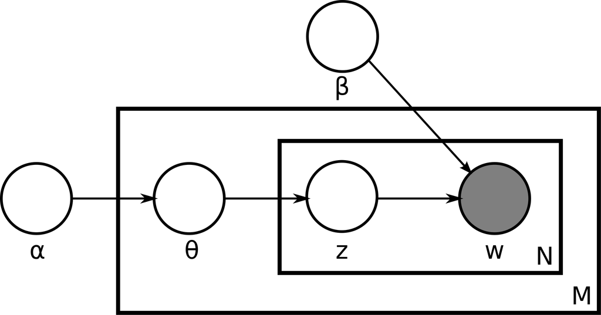

Obviously, this is not really how the documents in our corpus got created, however by making this generative assumption, it is possible to model the latent topic distribution in the corpus mathematically. In addition the generative aspect of LDA also solves a major headache, by implying that word order or context is irrelevant. With this generative mathematical framework it is possible to model processes like the probability of generating a word $v$ from topic $k$ $$ p(w_{dn} = v |z_{dn} = k) = \beta_{kv} $$ and the probability of selecting a specific topic $k$ for document $d$ $$ p(z_{dn} = k|\theta_d) = \theta_{dk} $$ The joint distribution for $\theta$, the predefined topics $z$ and the words $w$ is defined as $$ p(\theta , z, w|\alpha,\beta) = p(\theta |\alpha) \prod_n p(z_{n} |\theta_d ) p(w_{n}|\beta, z_{n}) $$ from this it is possible to derive the marginal distribution for a document, which can also be extended to the whole corpus $$ p(w|\alpha,\beta) = \int p(\theta |\alpha) \bigg( \prod_n \sum_{z_n} p(z_{n} |\theta ) p(w_{n}|\beta, z_{n})\bigg)d\theta \\ p(D|\alpha,\beta) = \prod_d\int p(\theta_d |\alpha) \bigg( \prod_n \sum_{z_n} p(z_{dn} |\theta_d ) p(w_{dn}|\beta, z_{dn})\bigg)d\theta_d $$ The marginal distribution however can not be calculated in reality, due to the latent factors involved. Therefore, it has to be approximated or to be inferred, which is why this problem is also commonly referred to as an Bayesian inference problem. The two most popular methods for approximating this distribution are Gibbs sampling and the Variational inference, which will be used in this example. While Gibbs sampling is unlike variational inference able to find a solution in which the bias reaches zero, under the assumption that it is given enough time, due to it being a Markov Chain Monte Carlo algorithm, the time complexity is infeasible high in comparison.

## Dirichlet distribution

The Dirichlet distribution, mathematically $Dir(\alpha)$ is a continuous multivariate probability distribution, whose density functions is defined by a parameter $\alpha$. Less formal the Dirichlet distribution can also be characterized as a distribution of distributions. The term multivariate in this context refers to describing multiple variables at once, in terms of the Dirichlet distribution, this refers for example to its property of being able to describe different multinomial distributions at every point of its distribution. The Dirichlet distribution is often used as prior distribution, meaning it is assumed to be known before accounting for evidence. With regards to why it is used as a prior distribution, the Dirichlet distribution is a conjugate prior( prior distribution belongs to the same distribution family as posterior distribution) to two of the most commonly used probability distributions, the multinomial distribution as outlined earlier and the categorical distribution. This simplifies inferring a parameter $\beta$ for a distribution from observation $x$. Mainly, if Bayes theorem is applied, the posterior distribution is equal to the likelihood function $p(x|\beta)$ times the prior $p(\beta)$ and the normalized by the probability of data $p(x)$. $$ p(\beta|x) = \frac{p(x|\beta)p(\beta)}{\int p(x|\beta')p(\beta')d\beta' } $$ Given that the likelihood function mostly originates from the data generating process, taking the integral becomes easier, if the prior, in this case the Dirichlet distribution, has the same algebraic form as the likelihood. With regards to the probability density function, it is defined as $$ P(\theta|\alpha) = \frac{\Gamma(\sum_{i=1}^k \alpha_i)}{\prod_{i=1}^k \Gamma (\alpha_i)} \theta_1^{a_1-1}...\theta_k^{a_k-1} $$ in which $\theta$ is a value between 0 and 1 and $\sum_{i=1}^k \theta_i =1$. The variable $\alpha$ is a k dimensional vector and determines the distribution of the Dirichlet distribution.

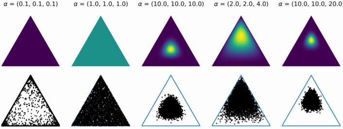

As it can observed in the example image above, displaying Dirichlet distribution with different $\alpha$ values, the closer the $\alpha$ values are to 1, the more evenly distributed the points in the Dirichlet distribution become. In general a Dirichlet distribution is referred to as being symmetric if all $\alpha$ values are the same, if this is not the case then it is a asymmetrical distribution. Another interesting property is that the higher the values for $\alpha$ are the more centered is the distribution around the mean.  
To provide an example for a Dirichlet distribution, lets imagine a dice factory being a Dirichlet distribution. This factory produces dices, which can also be viewed as Categorical distributions, because they only have discrete outcomes. If our factory had an $\alpha$ value that was symmetrical and 1, then some of the dices would be fair, but most would have a bias to one side. This is due to every point on the Dirichlet distribution representing a categorical distribution of one dice and as it can be observed in the example picture, in symmetrical distributions with an $\alpha$ of 1 the points are evenly distributed. Therefore, you would be much more likely to encounter a dice with an uneven categorical distribution, because there are fewer points in the middle. If now one value would be changed to 10, then the factory would mostly produce dices that are biased towards the number that gets represented by the edge on the Dirichlet distribution with the high $\alpha$ value. The optimal $\alpha$ value for the factory is therefore a very high symmetrical value, because it leads to most points centering on the mean, thus our factory produces a fair dice.  
Relating back to the Latent Dirichlet allocation, one can imagine, that every document is a point on a Dirichlet distribution, where the topics are the edges, each consisting out of a different mixture of topics, as depicted on the left side in the simplified example picture below. Every topic on the other hand is also a point on a Dirichlet distribution in which the edges are the words. The generative process of the Latent Dirichlet allocation model assumes then, that every document is created by drawing first from the Topic Dirichlet distribution a multinomial distribution, representing the topic distribution of the document. The N words are then drawn proportionally to the documents topic distribution from the Term Dirichlet distribution. For example if a document exhibits a high percentage of sport as a topic, then a high percentage of the words in the document are drawn from the Multinomial distribution representing sports on the Term Dirichlet distribution.

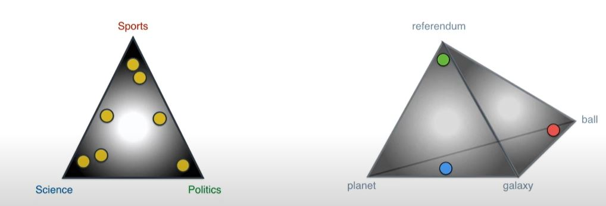

# Variational inference

Variational inference is a inference technique for problems that do belong to the group of Bayesian inference problem. Inference generally refers to inferring hidden/latent variables from variables that we can observer. The Bayesian inference applies a Bayesian statistical framework to this problem, where prior knowledge $p(H)$ is defined as a probability distribution that is updated each time a new observations $p(H|D)$ is made, that is defined as a different probability distribution. This is commonly known as Bayes Theorem

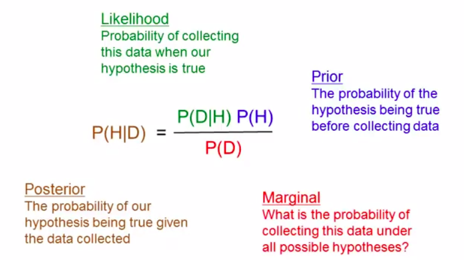

## Notation

$$ \begin{aligned} &{\vec{x}} = x_1 \dots x_n \textrm{ observations} \\ &{\vec{z}} = z_1 \dots z_m \textrm{ latent variables}\\ &\alpha\textrm{ fixed parameter of length m} \\ \end{aligned} $$

## Assumption

As outlined earlier, the goal is to find the posterior $$ \begin{equation} p(z|x,\alpha) = \frac{p(z,x|a)}{\int_z p(z,x|a)} \end{equation} $$
Given that the posterior is intractable to compute for large n and high dimensionality Therefore, a variational distribution can be created over the hidden variables in question in order to approximate the real distribution.
$$ \begin{equation} q(z_1 \dots z_m|v) \end{equation} $$
The goal is to approximate the variable $v$ so that $q = p$. The similarity of $q$ and $p$ can be measured by using the Kullback-Leibler Divergence. Expressed mathematically the similarity can therefore be defined as
$$ \begin{equation} KL(q||p) = \mathop{\mathbb{E_q}} \displaystyle \bigg[ \log \frac{q(z)}{p(z|x)} \bigg] \end{equation} $$
If $KL = 0$ the distributions are equal. Generally however the goal is not to approximate $q$ so that $KL = 0$, but finding an approximation that minimizes the Kullback-Leibler Divergence to an acceptable degree. This is process can be expressed as being on the search for a solution instead of searching the solution.

## Jensens Inequality

Jensens Inequality is an inequality that can be applied to concave or convex functions. Given that the log probability is a concave function, the definition of the inequality in terms of concave function is of interest. Jensens Inequality states, that if two points on a concave function are picked and you average the function $f(x)$ evaluated at the points, the result will be lower than the function $f(x)$ evaluated at the average of the two points. If the function would be convex, then the greater or equal sign would be flipped.
Expressed mathematically for a concave function:
$$ \begin{equation} f( \mathop{\mathbb{E}} [ X ] ) \geq \mathop{\mathbb{E}} [ f(X) ] \end{equation} $$

Below provided is an image displaying Jensens Inequality for convex and concave functions.

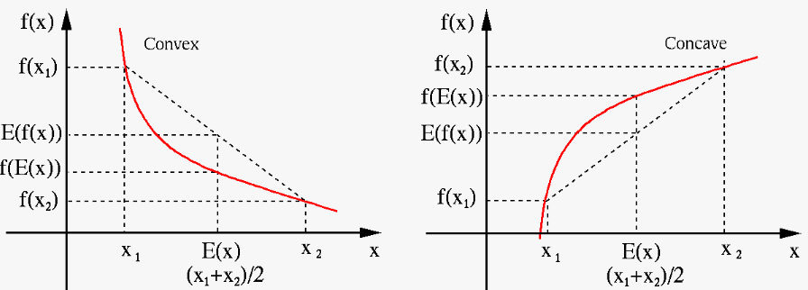

## Evidence Lower Bound (ELBO)

First the definition for the log probability of data is formed
$$ \begin{equation} \log \, p(x) = \log \displaystyle \bigg[\int_z p(x,z) \bigg] \end{equation} $$
Then the log probability of data is multiplied with a term that equals $1$. This introduces the approximation of $p$, $q$ into the equation
$$ \begin{equation} \log \, p(x) = \log \displaystyle \bigg[\int_z p(x,z) \frac{q(z)}{q(z)} \bigg] \end{equation} $$

The inner term of this new equation can be transformed to the expected value of $q$. This is possible, due to taking integral over the latent variables $z$, which matches the variable distribution, because it is also a distribution over the latent variables $z$
$$ \begin{equation} \log \, p(x) = \log \displaystyle \bigg[\mathop{\mathbb{E_q}}\displaystyle \bigg[\frac{p(x,z)}{q(z)}\bigg] \bigg] \end{equation} $$
Now Jensens Inequality can be applied to this function, given that log probability of data can be transformed to an expectation. The definition of Jensens Inequality for concave functions is used, due to the log probability of data being concave. $$ \begin{equation} \log \, p(x) = \log \displaystyle \bigg[\mathop{\mathbb{E_q}}\displaystyle \bigg[\frac{p(x,z)}{q(z)}\bigg] \bigg] \geq \mathop{\mathbb{E_q}}[\log \, p(x,z)] - \mathop{\mathbb{E_q}}[\log \, q(z)] \end{equation} $$
The application of Jensens Inequality on the function states, that by maximizing $ \mathop{\mathbb{E_q}}[\log \, p(x,z)] - \mathop{\mathbb{E_q}}[\log \, q(z)]$ a lower bound for the function is created, due to the term being lower or equal to the log probability. Therefore, while the actual log probability of data cannot be inferred a function that describes values, where the corresponding values of log probability of data can not be lower, can. A side effect is that right side represents the Entropy( uncertainty) of the variational distribution.

## Relation to the Kullback-Leibler Divergence

Conditional probability definition for $z$
$$ \begin{equation} p(z|x) = \frac{p(z,x)}{p(x)} \end{equation} $$
Plugged into the Kullback-Leibler Divergence
$$ \begin{equation} KL(q||p(z|x)) = \mathop{\mathbb{E_q}} \displaystyle \bigg[ \log \frac{q(z)}{p(z|x)} \bigg] \end{equation} $$
The log can be broken down into two parts, because it is a division, which yields a difference
$$ \begin{equation} KL(q||p(z|x)) = \mathop{\mathbb{E_q}} [ \log q(z)] - \mathop{\mathbb{E_q}} [ \log p(z|x)] \end{equation} $$
Since Conditional probability of $z$ got plugged into the equation, now $\frac{p(z,x)}{p(x)}$ can be applied to $\mathop{\mathbb{E_q}} [ \log p(z|x)]$, which yields another difference. $p(x)$ gets added to the term instead of subtracted, due to the term the conditional probability got applied to being negative. $\mathop{\mathbb{E_q}}$ falls away, because $p(x)$ does not relate to $q$. This yields:
$$ \begin{equation} KL(q||p(z|x)) = \mathop{\mathbb{E_q}} [ \log q(z)] - \mathop{\mathbb{E_q}} [ \log p(z|x)] + \log p(x) \end{equation} $$
By rearranging the term the negative ELBO is obtained plus the constant $\log p(x)$
$$ \begin{equation} KL(q||p(z|x)) = -(\mathop{\mathbb{E_q}} [ \log p(z|x)] - \mathop{\mathbb{E_q}} [ \log q(z)]) + \log p(x) \end{equation} $$
This relates back to observation that $q = p$ is achieved, if KL Divergence = 0. Given that $\log p(x) = \log \displaystyle \bigg[\mathop{\mathbb{E_q}}\displaystyle \bigg[\frac{p(x,z)}{q(z)}\bigg] \bigg] \geq \mathop{\mathbb{E_q}} [ \log p(z|x)] - \mathop{\mathbb{E_q}} [ \log q(z)]$, $\log p(x)$ will always be higher than the ELBO. Therefore, the KL divergence is minimized by maximizing the ELBO.

## Application of variational inference

Given that the problem can be framed as an optimization problem, it is now possible to approximate a solution by maximizing the ELBO through coordinate ascent. Once a type of variational distribution $q$ has been chosen (Mean Field etc). The objective becomes to derive the ELBO. Then Coordinate ascent is performed for each $q_i$ to maximize the ELBO until convergence. Coordinate ascent is an approach in which the maximum of a function is determined iteratively, by using the first derivative.  
The drawback with this approach is that the right type of variational distribution can not scientifically be determined. This leads in praxis to a trial and error approach in order to find the right distribution.

## Deriving variational inference for LDA

Recall the joint distribution in a previous section defined, but applied for every document in the corpus
$$ \begin{equation} p(\theta , z, w|\alpha,\beta) = \prod_d p(\theta_d |\alpha) \prod_n p(z_{d,n} |\theta_d ) p(w_{d,n}|\beta, z_{d,n}) \end{equation} $$
The joint distribution consists out of the following terms
$$ \begin{aligned} &p(\theta_d |\alpha) = \frac{ \Gamma(\sum_i a_i)}{\prod_i\Gamma(a_i) } \prod_k \theta_{d,k}^{\alpha_k -1} \textrm {(Dirichlet Mass function)}\\ &p(z_{d,n} |\theta_d ) = \theta_{d,z_{d,n}} \textrm {(Draw topic from Multinomial)}\\ &p(w_{d,n}|\beta, z_{d,n}) = \beta_{z_{d,n},w_{d,n}} \textrm {(Draw word from Multinomial)}\\ \end{aligned} $$
In LDA the variational distribution is assumed to be a mean field distribution. In addition, all $\theta$ and topic assignments( $z$) are assumed to be independent.
$$ \begin{equation} q(\vec{\theta},\vec{z}) = \prod_d q(\theta_d|\gamma_d) \prod_n q(z_{d,n}|\phi_{d,n}) \end{equation} $$
$\gamma$ is a Dirichlet distribution, because $\theta$ is Multinomial distribution, and Multinomial distributions originate from Dirichlet distribution.
$\phi$ is Multinomial distribution, due to $z$ being a discrete random variable.
Variational document distribution over topics $\gamma_d$.
Variational token distribution over topic assignment $\phi_{d,n}$.
Documents and tokens are vectors of the length K(number of topics)
With this the ELBO can be formed

$$ L(\gamma,\phi,\alpha,\beta) = \mathop{\mathbb{E_q}}[\log p(\theta |\alpha)] + \mathop{\mathbb{E_q}}[\log p(z |\theta)] + \mathop{\mathbb{E_q}}[\log p(w |z,\beta)] - \mathop{\mathbb{E_q}}[\log q(\theta)] - \mathop{\mathbb{E_q}}[\log q(z)] $$

Now the objective functions needs to be extended, in order to derive the algorithm. First $\mathop{\mathbb{E_q}}[\log p(\theta |\alpha)]$

$$\mathop{\mathbb{E_q}}[\log p(\theta |\alpha)] = \mathop{\mathbb{E_q}} \bigg[ \log \bigg( \frac{\Gamma(\sum_i \alpha_i)} {\prod_i \Gamma(\alpha_i)} \prod_i \theta_i^{\alpha_i-1} \bigg) \bigg]$$

The log of products can be transformed to sum of logs. $$\mathop{\mathbb{E_q}}[\log p(\theta |\alpha)] = \mathop{\mathbb{E_q}} \bigg[ \log \bigg( \frac{\Gamma(\sum_i \alpha_i)} {\prod_i \Gamma(\alpha_i)}\bigg) + \sum_i \log \theta_i^{\alpha_i-1} \bigg]$$ The log of the exponent on the right side can be transformed into a product. The left side of the term can be transformed to be a difference of logs and moved outside the expectation, because this is a constant that can be easily computed given alpha.
$$ \mathop{\mathbb{E_q}}[\log p(\theta |\alpha)] = \log \Gamma(\sum_i \alpha_i) - \sum_i \log \Gamma(\alpha_i) + \mathop{\mathbb{E_q}} \bigg[ \sum_i (\alpha_i-1) \log \theta_i \bigg] $$ Now the expectation of the $\log$ Dirichlet $\mathop{\mathbb{E}}_{dir}[\log p(\theta|\alpha)]= \Psi(\alpha_i) -\Psi(\sum_j \alpha_j) $, can be plugged in at $\log \theta_i$.
$$ \mathop{\mathbb{E_q}}[\log p(\theta |\alpha)] = \log \Gamma(\sum_i \alpha_i) - \sum_i \log \Gamma(\alpha_i) + \sum_i (\alpha_i-1) \bigg( \Psi(\gamma_i) -\Psi(\sum_j \gamma_j) \bigg) $$
Now to continue with $\mathop{\mathbb{E_q}}[\log p(z |\theta)]$ (Expectation of topics assignment given document distribution over topics)
$$ \mathop{\mathbb{E_q}}[\log p(z |\theta)] = \mathop{\mathbb{E_q}} \bigg[\log \prod_n \prod_i \theta_i^{\mathop{\mathbb{1}} [z_n==i]} \bigg] $$ First we transform the products to sum of logs $$ \mathop{\mathbb{E_q}}[\log p(z |\theta)] = \mathop{\mathbb{E_q}} \bigg[ \sum_n \sum_i \log\theta_i^{\mathop{\mathbb{1}} [z_n==i]} \bigg] $$ Then linearity of expectations is used to move the expectation in front of the sums. To explain linearity of expectations it is the observation, that the expected value of the sum of random values is equal to the sum of the expected values of the independent values and dependent or not does not influence this. As an example the expected value for throwing a dice twice is the sum of the expected values for each dice throw being $3.5 +3.5 = 7$ $$ \mathop{\mathbb{E_q}}[\log p(z |\theta)] = \sum_n \sum_i \mathop{\mathbb{E_q}} \bigg[\log\theta_i^{\mathop{\mathbb{1}} [z_n==i]} \bigg] $$ The expectation of the indicator function $\mathop{\mathbb{1}} [z_n==i]$ (Probability of token i being assigned to topic $z_n$) in $p$ becomes the variational distribution over topic assignments in q and can thus be moved outside $\mathop{\mathbb{E_q}}$ as $\phi_{ni}$. This is possible, because q is a distribution over the latent variables and the indicator function expresses how likely it is that this token is assigned to a topic, which can also be expressed by the variational distribution. $$ \mathop{\mathbb{E_q}}[\log p(z |\theta)] = \sum_n \sum_i \phi_{ni} \mathop{\mathbb{E_q}}[\log\theta_i ] $$ Now the expectation of the log Dirichlet can be plugged in at $\mathop{\mathbb{E_q}}[\log\theta_i ]$ $$ \mathop{\mathbb{E_q}}[\log p(z |\theta)] = \sum_n \sum_i \phi_{ni} \bigg( \Psi(\gamma_i) -\Psi(\sum_j \gamma_j) \bigg) $$
Then the expectation of a word given a topic assignment $z$ and a topic $\beta$, $\mathop{\mathbb{E_q}}[\log p(w |z,\beta)]$, needs to be transformed.
$$ \mathop{\mathbb{E_q}}[\log p(w |z,\beta)] = \mathop{\mathbb{E_q}}[\log\beta_{z_{d,n},w_{d,n}}] $$
The term then gets expanded, to included all terms in the vocabulary and all possible topics. In order to expand the term an indicator function is added ${\mathop{\mathbb{1}} [v=w_{d,n},z_{d,n}=i]}$. Which indicate whether index of the topic distribution $v$ matches word $w_{d,n}$ and if topic of the token $z_{d,n}$ is assigned to $i$. $$ \mathop{\mathbb{E_q}}[\log p(w |z,\beta)] = \mathop{\mathbb{E_q}} \bigg[ \log \prod_v^V \prod_k^K \beta_{i,v}^{\mathop{\mathbb{1}} [v=w_{d,n},z_{d,n}=i]} \bigg] $$ Now the products can be moved outside the expectations as sums. Then the exponent of the log gets taken and $\log \beta_{i,v}$ can be moved outside of the expectation, because it does not depend on the variational distribution, which only governs $\theta$ and $z$. $$ \mathop{\mathbb{E_q}}[\log p(w |z,\beta)] = \sum_v^V \sum_k^K \mathop{\mathbb{E_q}} [\mathop{\mathbb{1}} [v=w_{d,n},z_{d,n}=i]]\log \beta_{i,v} $$ The indicator function can then be simplified to the probability of this token taken on a topic ($\phi_{n,i}$) times the probability, whether the word is $v$ ($ w_{d,n}^v$) $$ \mathop{\mathbb{E_q}}[\log p(w |z,\beta)] = \sum_v^V \sum_k^K \phi_{n,i} w_{d,n}^v \log \beta_{i,v} $$ Now all the expectations for the objective function $L$ are formed and the only remaining terms are the entropy terms for the Dirichlet distribution $\mathop{\mathbb{E_q}}[\log q(\theta)]$ and for the Multinomial distribution $\mathop{\mathbb{E_q}}[\log q(z)]$.
The Entropy term for the Dirichlet distribution is defined as
$$ \mathop{\mathbb{H_q}}[\gamma] = -\log \Gamma \bigg(\sum_j \gamma_j \bigg) + \sum_i \log \Gamma (\gamma_i) - \sum_i(\gamma_i - 1) \bigg( \Psi(\gamma_i) -\Psi(\sum_{j=1}^k \gamma_j) \bigg) $$
The Entropy term of the Multinomial distribution is defined as
$$ \mathop{\mathbb{H_q}}[\phi_{d,n}] = -\sum_i \phi_{d,n,i} \log\phi_{d,n,i} $$
Now all expanded terms can be plugged into the objective function yielding $$ \begin{aligned} L(\gamma,\phi,\alpha,\beta) &= \log \Gamma(\sum_{j=1}^k \alpha_j) - \sum_{i=1}^k \log \Gamma(\alpha_i) + \sum_{i=1}^k (\alpha_i-1) \bigg( \Psi(\gamma_i) -\Psi(\sum_{j=1}^k \gamma_j) \bigg) \\ &+ \sum_{n=1}^N \sum_{i=1}^k \phi_{ni} \bigg( \Psi(\gamma_i) -\Psi(\sum_{j=1}^k \gamma_j) \bigg) \\ &+ \sum_{n=1}^N \sum_{i=1}^k \sum_{j=1}^V \phi_{n,i} w_n^j \log \beta_{i,j} \\ &-\log \Gamma \bigg(\sum_{j=1}^k \gamma_j \bigg) + \sum_{i=1}^k \log \Gamma (\gamma_i) - \sum_{i=1}^k(\gamma_i - 1) \bigg( \Psi(\gamma_i) -\Psi(\sum_{j=1}^k \gamma_j) \bigg) \\ &-\sum_{n=1}^N \sum_{i=1}^k \phi_{d,n,i} \log\phi_{d,n,i} \end{aligned} $$

## Deriving the algorithm

Given that this function needs to be maximized, coordinate ascent is performed on it. In order to perform coordinate ascent the derivative of $L$ with respect to the parameters $\phi$(phi), $\gamma$(gamma) and $\beta$(beta) needs to be taken. To perform this step, $L$ is set to zero and the partial derivative is computed, by solving for the variable of interest.
The partial derivative of $L$ with respect to $\phi_{ni}$ is defined as $$ \frac{\partial L }{\partial \phi_{ni}} = \Psi(\gamma_i) -\Psi(\sum_j \gamma_j) + \log \beta_{i,v} - \log \phi_{ni} -1 + \lambda $$ Then the term is set to zero and solved for $\phi_{ni}$. The resulting term is just a proportional result due to $\phi$ being inside a log, which results in many terms falling away when solving for it. $$ \phi_{ni} \propto \beta_{i,v} \exp \bigg( \Psi(\gamma_i) -\Psi(\sum_j \gamma_j) \bigg) $$ Implementation wise, $\beta$ is a k dimensional vector representing, the probability of a word being one of the k topics and $\bigg( \Psi(\gamma_i) -\Psi(\sum_j \gamma_j) \bigg)$ is also a k dimensional vector representing the topic distribution of the document.
The partial derivative of $L$ with respect to $\gamma_i$ is defined as

$$ \frac{\partial L }{\partial \gamma_{i}} = \Psi'(\gamma_i) (\alpha_i + \sum_n\phi_{n,i} - \gamma_i) - \Psi'(\sum_j\gamma_j) \sum_j(\alpha_j + \sum_n\phi_{n,j} - \gamma_j) \\ \\ \textrm{Note: }\Psi' \textrm{ is the derivative of the Digamma function} $$

Then the term is set to zero and solved for $\gamma_i$. Given that the only way the equation being zero is achieved if $(\alpha_i + \sum_n\phi_{n,i} - \gamma_i)$ and $(\alpha_j + \sum_n\phi_{n,j} - \gamma_j)$ equal zero, solving for $\gamma_i$ can be simplified, to just solving these parts of the equation. $$ \gamma_i = \alpha_i + \sum_n\phi_{n,i} $$ Implementation wise, the algorithm adds up all the words phis in a document, which is a k dimensional vector and adds the Dirichlet parameter $\alpha$ to it. The result is then stored in matrix of form D( number of documents) height and K length for higher memory efficiency and vectorization of the calculations.
To find the partial derivative of $L$ with respect to $\beta_{ij}$ the Lagrange parameter is required. Once the term is formed solving for $\beta_{ij}$, yields a proportional result, because $\beta_{ij}$ is inside a $\log$ $$ \beta_{ij} \propto \sum_d \sum_n \phi_{dni} w_{dn}^j $$ Implementation wise, $\beta$ is a matrix with a length of K( number of topics) and a height of V( number unique vocabs in corpus). Given that the row index represents a word, the matrix is basically a collection of vectors that represent the topic distribution of the given word. In order to update beta, the phi values of the different words are added up over the corpus for every word and then divided by the total. The result is then stored in matrix form for higher memory efficiency and vectorization of the calculations.
With these formulas it is now possible to program an algorithm that is able to perform variational inference for Latent Dirichlet allocation.

## Implementation

First a word index and a reversed word index are formed as dictionaries in order to transform the articles into bag of words. Then the articles are transformed into bag of words form and transformed into a sparse matrix. Bag of words are used, because LDA assumes that the word order is not important to determine the meaning. With the calculations defined earlier the training is implemented. Implementation wise instead of looping through the document matrix, the algorithm loops through the columns of the the term topic matrix in order to speed the code up.

```python
class LDA:
    """
    Assumes that text is entered as pandas dataframe with the field "tokenized_body" holding all the relevant data.
    """
    def __init__(self,articles,K):
        self.articles = articles
        # Creates Word to id mapping and inverse
        self.word_dic = self.create_word_dic(self.articles["tokenized_body"])
        self.word_dic_inverted =  dict(map(reversed, self.word_dic.items()))
        self.topics = list(range(0,K))
        # Creates bag of words
        self.articles_to_bagofwords_vectors(self.articles["tokenized_body"])
        self.create_matrices_inference()

    """
    Assigns unique id to every word
    """
    def create_word_dic(self,article_list):
        word_dic = {}
        counter= 0
        for article in article_list:
            for word in article:
                word_dic.setdefault(word,None)

        for key in word_dic:
            word_dic[key] = counter
            counter = counter +1
        return word_dic

    """
    Initalizes relevant parameters randomly
    """
    def create_matrices_inference(self):
        #transform tokenized body into bag of words
        numpy.random.seed(4)
        self.term_topic_matrix = numpy.random.dirichlet(numpy.ones(len(list(self.word_dic))),size = len(self.topics)).T
        # random assigment of numbers
        self.document_topic_matrix = numpy.full((len(self.articles),len(self.topics)),2)
        #assuming to be uniformly distributed in the beginning

    """
    Converts articles to bag of words
    """
    def articles_to_bagofwords_vectors(self,article_list):
        counter = 0
        col_index = []
        row_index = []
        values = []
        for article_index in range(0,len(article_list)):
            counter +=1
            print(counter)
            article = article_list[article_index]
            bag_of_words = dict()


            for token in article:
                token = self.word_dic[token]
                if token in bag_of_words:
                    bag_of_words[token] +=1
                else:
                    bag_of_words[token] =1
            for key, value in bag_of_words.items():
                col_index.append(key)
                row_index.append(article_index)
                values.append(value)
        values = numpy.array(values, dtype=float)
        col_index= numpy.array(col_index, dtype=float)
        row_index= numpy.array(row_index, dtype=float)
        converted_articles= scipy.sparse.coo_matrix((values, (row_index, col_index)), shape=(len(article_list), len(self.word_dic)))

        self.document_word_matrix =  scipy.sparse.csc_matrix(converted_articles)

    def calc_phi(self):
        list_of_phis = []
        phis_added_up = 0
        for topic_index in range(0,len(self.topics)):
            all_phis_for_topic = self.document_word_matrix.multiply(self.term_topic_matrix[:,topic_index]).T.multiply(numpy.exp((scipy.special.digamma(self.document_topic_matrix).T - scipy.special.digamma(numpy.sum(self.document_topic_matrix,axis=1))).T)[:,topic_index])
            list_of_phis.append(all_phis_for_topic)

            phis_added_up += all_phis_for_topic
        for topic_index in range(0,len(self.topics)):

            list_of_phis[topic_index] = sparse_divide_nonzero(list_of_phis[topic_index] ,phis_added_up)

        return list_of_phis


    """
    Function to train the model
    """
    def train_inference(self,iterations,alpha):
        self.alpha = numpy.array(alpha)

        for i in range(0,iterations):
            print(i)

            #calc phi
            phi = self.calc_phi()
            gamma = numpy.zeros((len(self.articles),len(self.topics)))
            #calculate gamm based on phi
            for m_index in range(0,len(phi)):
                gamma[:,m_index] = phi[m_index].sum(axis=0)
            # update document topic distribution
            self.document_topic_matrix = gamma +self.alpha
            # calc phi again with new document topic distribution
            phi = self.calc_phi()
            beta = numpy.zeros((len(list(self.word_dic)),len(self.topics)))
            # calc beta with phi
            for m_index in range(0,len(phi)):
                beta[:,m_index] = numpy.divide(phi[m_index].sum(axis=1),numpy.sum(phi[m_index].sum(axis=1))).T

            # beta is the new term topic distribution
            self.term_topic_matrix = beta


    """
    Returns top kth terms most associated with each topic
    """
    def word_associated_topics(self,kth):
        output = []
        ordered_matrix = numpy.argpartition(self.term_topic_matrix, -kth,axis=0)[-kth:]
        for i in range(0,kth):
            ith_array = []
            for e in range(0,len(self.topics)):
                index = ordered_matrix[kth-i-1,e]
                ith_array.append(self.word_dic_inverted[int(index)])
            output.append(ith_array)
        return pd.DataFrame(output)


    """
    Returns the learned topic distribution
    """
    def return_topic_distribution(self):
        return numpy.divide(self.document_topic_matrix.T,numpy.sum(self.document_topic_matrix,axis=1)).T
```

```python
lda = LDA(articles = df, K=35)
```

In terms of the parameter $\alpha$, since We do not have any initial knowledge about the topic distribution in the dataset, I picked a symmetrical and equally distributed value.

```python
#iteration is printed each iteration
lda.train_inference(alpha=[1,1,1,1,1,1,1,1,1,1,1,1,1,1,1,1,1,1,1,1,1,1,1,1,1,1,1,1,1,1,1,1,1,1,1],iterations=40)
```

```
0
1
2
3
4
5
6
7
8
9
10
11
12
13
14
15
16
17
18
19
20
21
22
23
24
25
26
27
28
29
30
31
32
33
34
35
36
37
38
39
```

The function below is used in order to inspect the results of the model. It will return a list, in which each column represents one topic. The rows represent the words that are the most associated with the given topic. The value passed to the function represents the number of words most associated to a topic that will get returned.

```python
print(lda.word_associated_topics(20))
```

```
         0         1       2           3         4         5          6   \
0    intern      cnbc     buy       creat    export       com       cash
1       oil       lot     oil         say   countri      call       deal
2     middl      told    mani        want      grow     money        ceo
3      east   probabl  market         tri     india      cnbc    compani
4    attack    believ    make        must    demand     stock        pay
5     state      like     one      import    import   suggest      offer
6      arab      long    good        issu      year   comment       firm
7     world       get  happen   interview     boost  question      manag
8    arabia     think    look  understand     china     think     servic
9    aramco       see     may       right      fuel    websit      share
10    saudi  investor    quit        time   product       oil      mobil
11  kingdom      term    read       chang       oil      like       base
12     said        go    take    question   million       buy       valu
13   energi    realli  recent     address    accord    cramer       busi
```

[output cut: 52 more lines]

# Interpreting the results

As can be seen above, we are giving a matrix in which each column represents a topic. It is now on us in order to determine, what topics are found and whether they are useful. Remember that the words that are displayed are in tokenized form.

As an example, when analyzing the results, it is quite obvious that for example, the first column refers to a topic, that can be loosely described as middle east. Whereas column 8 seems to refer to a topic that could be described as europe. A non geographic topic that got discovered can be seen in column 9 for example, since this topic seems to be primarly associated with words that do belong to the energy section.

# Sources

[1] Blei, David M., Andrew Y.Ng und Micheal I.Jordan : "Latent Dirichlet Allocation" 2003

[2] Warren S. McCulloch and Walter Pitts : "A logical calculus of the ideas immanent in nervous activity" 1943

[3] Moshe Leshno, Vladimir Ya. Lin, Allan Pinkus and Shimon Schocken : "Multilayer Feedforward Networks With a Nonpolynomial Activation Function Can Approximate Any Function" 1993

[4] Westerveld, Thijs, Arjen de Vries, and Franciska de Jong: "Generative Probabilistic Models". 2007